# Activity monitoring analysis

It is now possible to collect a large amount of data about personal movement using activity monitoring devices such as a Fitbit, Nike Fuelband, or Jawbone Up. These type of devices are part of the “quantified self” movement – a group of enthusiasts who take measurements about themselves regularly to improve their health, to find patterns in their behavior, or because they are tech geeks. But these data remain under-utilized both because the raw data are hard to obtain and there is a lack of statistical methods and software for processing and interpreting the data.

```r
library(doBy)
library(chron)
library(ggplot2)
act = read.csv("activity.csv", header = T)
summary = summaryBy(steps ~ date, data = act, FUN = list(sum, mean))

names(summary) = c("date", "steps_Sum", "steps_Mean")
summary[,1:2]
```

```
##          date steps_Sum
## 1  2012-10-01        NA
## 2  2012-10-02       126
## 3  2012-10-03     11352
## 4  2012-10-04     12116
## 5  2012-10-05     13294
## 6  2012-10-06     15420
## 7  2012-10-07     11015
## 8  2012-10-08        NA
## 9  2012-10-09     12811
## 10 2012-10-10      9900
## 11 2012-10-11     10304
## 12 2012-10-12     17382
## 13 2012-10-13     12426
## 14 2012-10-14     15098
```

[output cut: 47 more lines]

Following is the histogram of the number of steps taken

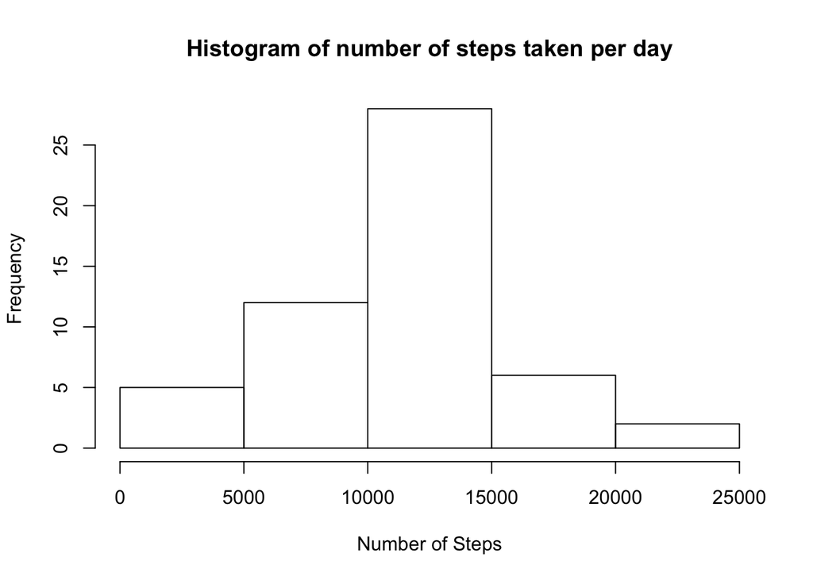

Following is the mean of the number of steps taken per day is 10766.2 and the median of the values is 10765

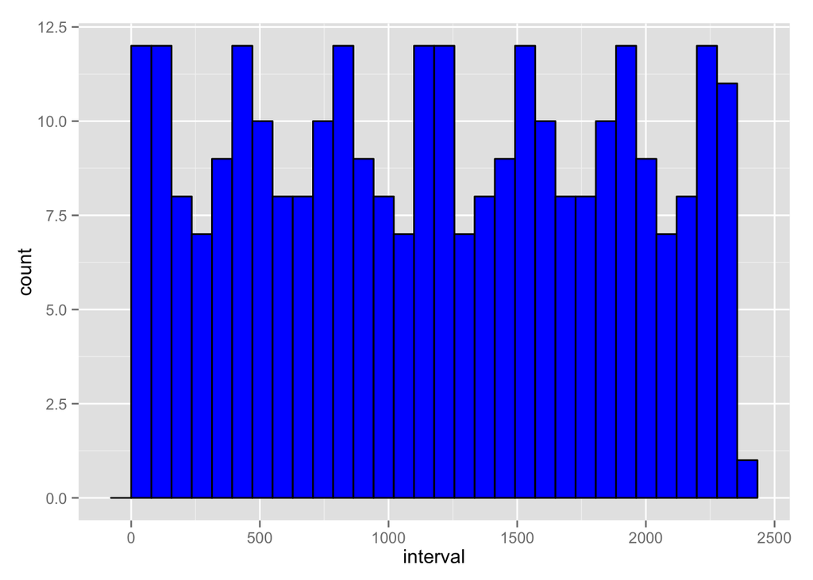

Following is the number of NA values in the dataset is 2304

[figure not shown]

To substitute the missing values, we use the average steps taken per day(with the NA values) and put them into the previously NA fields in the steps column.

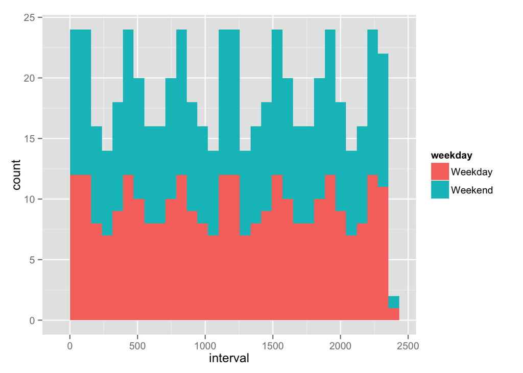